# Reproducibility Report: Group B Choice 3

For this exercise, please try to reproduce the results from Experiment 2 of the associated paper (de la Fuente, Santiago, Roman, Dumitrache, & Casasanto, 2014). The PDF of the paper is included in the same folder as this Rmd file.

#### Methods summary:

Researchers tested the question of whether temporal focus differs between Moroccan and Spanish cultures, hypothesizing that Moroccans are more past-focused, whereas Spaniards are more future-focused. Two groups of participants ($N = 40$ Moroccan and $N=40$ Spanish) completed a temporal-focus questionnaire that contained questions about past-focused (“PAST”) and future-focused (“FUTURE”) topics. In response to each question, participants provided a rating on a 5-point Likert scale on which lower scores indicated less agreement and higher scores indicated greater agreement. The authors then performed a mixed-design ANOVA with agreement score as the dependent variable, group (Moroccan or Spanish, between-subjects) as the fixed-effects factor, and temporal focus (past or future, within-subjects) as the random effects factor. In addition, the authors performed unpaired two-sample t-tests to determine whether there was a significant difference between the two groups in agreement scores for PAST questions, and whether there was a significant difference in scores for FUTURE questions.

#### Target outcomes:

Below is the specific result you will attempt to reproduce (quoted directly from the results section of Experiment 2):

> According to a mixed analysis of variance (ANOVA) with group (Spanish vs. Moroccan) as a between-subjects factor and temporal focus (past vs. future) as a within-subjectS factor, temporal focus differed significantly between Spaniards and Moroccans, as indicated by a significant interaction of temporal focus and group, F(1, 78) = 19.12, p = .001, ηp2 = .20 (Fig. 2). Moroccans showed greater agreement with past-focused statements than Spaniards did, t(78) = 4.04, p = .001, and Spaniards showed greater agreement with future-focused statements than Moroccans did, t(78) = −3.32, p = .001. (de la Fuente et al., 2014, p. 1685).

# Step 1: Load packages

```r
library(tidyverse) # for data munging
library(knitr) # for kable table formating
library(haven) # import and export 'SPSS', 'Stata' and 'SAS' Files
library(readxl) # import excel files

# #optional packages/functions:
library(afex) # anova functions
library(ez) # anova functions 2
library(scales) # for plotting
std.err <- function(x) sd(x)/sqrt(length(x)) # standard error
```

# Step 2: Load data

```r
# Just Experiment 2
data_path <- 'data/DeLaFuenteEtAl_2014_RawData.xls'
d <- read_excel(data_path, sheet=3)
```

# Step 3: Tidy data

```r
# data are already tidy
```

# Step 4: Run analysis

## Pre-processing

```r
# rename column with rating data
d <- d %>%
       rename("rating" = "Agreement (0=complete disagreement; 5=complete agreement)")

# maybe drop NaNs?
```

```r
# change data structure
d$participant<-as.factor(d$participant)
d$group<-as.factor(d$group)
d$subscale<-as.factor(d$subscale)
d$item<-as.factor(d$item)
str(d)
```

```
## tibble [1,680 × 5] (S3: tbl_df/tbl/data.frame)
##  $ group      : Factor w/ 2 levels "Moroccan","young Spaniard": 1 1 1 1 1 1 1 1 1 1 ...
##  $ participant: Factor w/ 40 levels "1","2","3","4",..: 1 1 1 1 1 1 1 1 1 1 ...
##  $ subscale   : Factor w/ 2 levels "FUTURE","PAST": 2 2 2 2 2 2 2 2 2 2 ...
##  $ item       : Factor w/ 21 levels "1. Para mí son muy importantes las tradiciones y las antiguas costumbres",..: 1 12 15 16 17 18 19 20 21 2 ...
##  $ rating     : num [1:1680] 4 4 5 2 4 3 4 2 2 3 ...
```

```r
# remove participant 25

#excluded <- "25"

#d <- d %>% filter(!participant %in% excluded) #participant exclusions
```

```r
# drop items column, then remove duplicate entries...
d  = subset(d, select = -c(item) )
```

```r
d2 <- d  %>% distinct()
```

```r
# would like to know what groups are there..
unique(d$group)
```

```
## [1] Moroccan       young Spaniard
## Levels: Moroccan young Spaniard
```

```r
unique(d$participant)
```

```
##  [1] 1  2  3  4  5  6  7  8  9  10 11 12 13 14 15 16 17 18 19 20 21 22 23 24 40
## [26] 25 26 27 28 29 30 31 32 33 34 35 36 37 38 39
## 40 Levels: 1 2 3 4 5 6 7 8 9 10 11 12 13 14 15 16 17 18 19 20 21 22 23 ... 40
```

## Descriptive statistics

Try to recreate Figure 2 (fig2.png, also included in the same folder as this Rmd file):

```r
# group by Moroccan, PAST or FUTURE, and calc mean and standard error
# same for spanish

groups <- d %>% group_by(group, subscale)  %>% summarise(avg = mean(rating), std_err = std.err(rating))
```

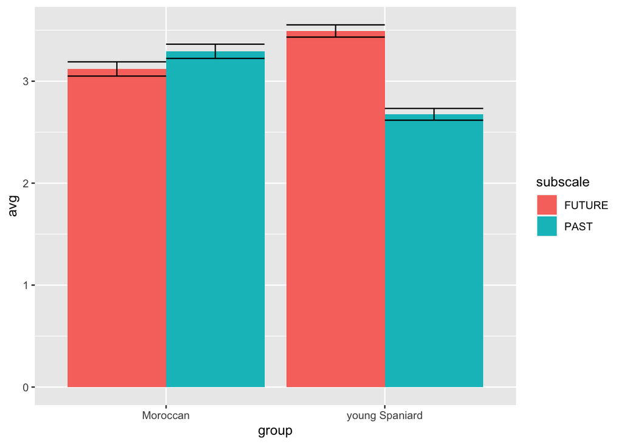

```r
ggplot(groups, aes(x=group, weight=avg, ymin=avg-std_err, ymax=avg+std_err, fill=subscale)) +
     geom_bar      (position=position_dodge(), aes(y=avg), stat="identity") +
     geom_errorbar (position=position_dodge(), colour="black")
```

## Inferential statistics

> According to a mixed analysis of variance (ANOVA) with group (Spanish vs. Moroccan) as a between-subjects factor and temporal focus (past vs. future) as a within-subjects factor, temporal focus differed significantly between Spaniards and Moroccans, as indicated by a significant interaction of temporal focus and group, F(1, 78) = 19.12, p = .001, ηp2 = .20 (Fig. 2).

```r
# take 1, mixed models
#fit_nice <- aov_ez("participant","rating",d,between=c("group"),within=c("subscale"),return="nice")
```

```r
# take 2, mixed models
fit_mixed <- mixed(rating~group*subscale+(group|participant),data=d)
```

```r
# results -> df is off..
fit_mixed
```

```
## Mixed Model Anova Table (Type 3 tests, S-method)
##
## Model: rating ~ group * subscale + (group | participant)
## Data: d
##           Effect         df         F p.value
## 1          group   1, 41.69      2.80    .102
## 2       subscale 1, 1610.45 25.14 ***   <.001
## 3 group:subscale 1, 1609.67 59.58 ***   <.001
## ---
## Signif. codes:  0 '***' 0.001 '**' 0.01 '*' 0.05 '+' 0.1 ' ' 1
```

```r
# take 3, mixed models... df is half of what it should be
aov.1 <- aov_car(rating ~ group*subscale + Error(participant/(group*subscale)), data=d2)
aov.1
```

```
## Anova Table (Type 3 tests)
##
## Response: rating
##           Effect    df  MSE        F  ges p.value
## 1          group 1, 38 0.16     1.81 .011    .187
## 2       subscale 1, 38 0.21  8.53 ** .061    .006
## 3 group:subscale 1, 38 0.23 12.12 ** .094    .001
## ---
## Signif. codes:  0 '***' 0.001 '**' 0.01 '*' 0.05 '+' 0.1 ' ' 1
```

> Moroccans showed greater agreement with past-focused statements than Spaniards did, t(78) = 4.04, p = .001,

```r
# reproduce the above results here -> df is wrong
m_rate <- d2 %>% filter(group == "Moroccan", subscale== "PAST") %>% select(rating)
s_rate <- d2 %>% filter(group == "young Spaniard", subscale== "PAST") %>% select(rating)
t.test(m_rate, s_rate,)
```

```
##
##  Welch Two Sample t-test
##
## data:  m_rate and s_rate
## t = 2.034, df = 291.59, p-value = 0.04285
## alternative hypothesis: true difference in means is not equal to 0
## 95 percent confidence interval:
##  0.01032782 0.62736677
## sample estimates:
## mean of x mean of y
##  3.072368  2.753521
```

> and Spaniards showed greater agreement with future-focused statements than Moroccans did, t(78) = −3.32, p = .001.(de la Fuente et al., 2014, p. 1685)

```r
# reproduce the above results here
m_rate <- d2 %>% filter(group == "Moroccan", subscale== "FUTURE") %>% select(rating)
s_rate <- d2 %>% filter(group == "young Spaniard", subscale== "FUTURE") %>% select(rating)
t.test(m_rate, s_rate,)
```

```
##
##  Welch Two Sample t-test
##
## data:  m_rate and s_rate
## t = -1.1614, df = 310.01, p-value = 0.2464
## alternative hypothesis: true difference in means is not equal to 0
## 95 percent confidence interval:
##  -0.4810321  0.1239411
## sample estimates:
## mean of x mean of y
##  3.031646  3.210191
```

> I have reached the three hour limit of time to work on this.

# Step 5: Reflection

Were you able to reproduce the results you attempted to reproduce? If not, what part(s) were you unable to reproduce?

> I was able to reproduce the desciptive bar plot. However, my statistical tests came out with the wrong degrees of freedom, and were thus incorrect.

How difficult was it to reproduce your results?

> Very difficult.

What aspects made it difficult? What aspects made it easy?

> This was difficult because I am not sure what the authors did to the data in order to get n=78. I tried different pre-processing schemes and various functions for a task, but could not get the correct result. It was easy to understand the experimemts the authors carried out, but difficult to reproduce their statistics.